# Projekt ZED

Paweł Pytel 136786

2021-12-11

# Executive summary

Raport przedstawia analizę czynników rozwoju dla różnych krajów na przestrzeni lat, analizę ceny złota, ceny Bitcoina oraz współczynnika S&P Composite. Po wstępnym przetwarzaniu danych wyłoniono 5 krajów o różnej zamożności i dokonano dla nich przeglądu czynników rozwoju. Pokazano także zmiany w cenie złota, Bitcoina oraz współczynnika S&P Composite w czasie. Następnie przeanalizowano korelację atrybutów z ceną złota i ceną Bitcoina. Wyłoniono Stany Zjednoczone jako kraj, którego czynniki rozwoju są najbardziej skorelowane z ceną złota.Pokazano zmienność tych czynników względem ceny złota w czasie. Następnie podjęto próbę stworzenia regresora przewidującego cenę złota, korzystając z danych dotyczących Stanów Zjednoczonych, ceny Bitcoina oraz współczynnika S&P Composite. Na końcu przeprowadzono analizę ważności atrybutów w wytrenowanym modelu.

# Kod wyliczający wykorzystane biblioteki

```r
knitr::opts_chunk$set(echo = TRUE)
knitr::opts_chunk$set(message = FALSE)
knitr::opts_chunk$set(warning = FALSE)
library(dplyr)
library(tidyr)
library(ggplot2)
library(readxl)
library(zoo)
library(corrplot)
library(gganimate)
library(gifski)
library(caret)
library(randomForest)
```

# Kod zapewniający powtarzalność wyników przy każdym uruchomieniu raportu na tych samych danych

```r
set.seed(23)
```

# Kod pozwalający wczytać dane z pliku

```r
WorldDevelopmentIndicators <- read_excel("data/World_Development_Indicators.xlsx")
GoldPrices <- read.csv("data/Gold prices.csv")
BitcoinPrices <- read.csv("data/Bitcoin/BCHAIN-MKPRU.csv")
SPComposite <- read.csv("data/S&P Composite.csv")
```

# Kod czyszczący dane

## World Development Indicators

```r
WorldDevelopmentIndicators <- WorldDevelopmentIndicators %>%
  filter(!(is.na(`Country Code`) | `Country Code` == "")) %>%
  rename(CountryName = `Country Name`, SeriesName = `Series Name`) %>%
  select(-`Country Code`,-`Series Code`) %>%
  gather("Year", "Value", `1970 [YR1970]`:`2020 [YR2020]`)
WorldDevelopmentIndicators$SeriesName <-
  gsub("\\$", " Dollar", WorldDevelopmentIndicators$SeriesName)
WorldDevelopmentIndicators$Year <-
  as.numeric(substr(WorldDevelopmentIndicators$Year, 0, 4))
WorldDevelopmentIndicators$Value[WorldDevelopmentIndicators$Value == ".."] <-
  NA
WorldDevelopmentIndicators$Value <-
  as.numeric(WorldDevelopmentIndicators$Value)
tmp <-
  mutate(WorldDevelopmentIndicators, IsValueEmpty = is.na(Value)) %>%
  group_by(CountryName, SeriesName) %>%
  summarize(
    IsValueEmptySum = sum(IsValueEmpty, na.rm = TRUE),
    YearDifference = max(Year) - min(Year) + 1
  ) %>%
  filter(IsValueEmptySum == YearDifference) %>%
  group_by(CountryName) %>%
  summarize(emptyAttributesCount = n()) %>%
  filter(emptyAttributesCount < quantile(emptyAttributesCount, 0.5))
WorldDevelopmentIndicators <- WorldDevelopmentIndicators %>%
  filter(CountryName %in% tmp$CountryName) %>%
  spread(SeriesName, Value)
WorldDevelopmentIndicators <-
  WorldDevelopmentIndicators[, colSums(is.na(WorldDevelopmentIndicators)) < quantile(colSums(is.na(WorldDevelopmentIndicators)), 0.2)]
WorldDevelopmentIndicators <- WorldDevelopmentIndicators %>%
  mutate(
    `Exports of goods and services (current US Dollar per capita)` = `Exports of goods and services (current US Dollar)` /
      `Population, total`,
    `Imports of goods and services (current US Dollar per capita)` = `Imports of goods and services (current US Dollar)` /
      `Population, total`,
    `Methane emissions (kt of CO2 equivalent per capita)` = `Methane emissions (kt of CO2 equivalent)` /
      `Population, total`,
    `Nitrous oxide emissions (thousand metric tons of CO2 equivalent per capita)` = `Nitrous oxide emissions (thousand metric tons of CO2 equivalent)` /
      `Population, total`,
    `Number of under-five deaths (per capita)` = `Number of under-five deaths` /
      `Population, total`,
    `Total greenhouse gas emissions (kt of CO2 equivalent per capita)` = `Total greenhouse gas emissions (kt of CO2 equivalent)` /
      `Population, total`
  ) %>%
  select(
    CountryName,
    Year,
    `Birth rate, crude (per 1,000 people)`,
    `CO2 emissions (metric tons per capita)`,
    `Exports of goods and services (current US Dollar per capita)`,
    `GDP per capita (current US Dollar)`,
    `Imports of goods and services (current US Dollar per capita)`,
    `Land area (sq. km)`,
    `Life expectancy at birth, total (years)`,
    `Merchandise exports to high-income economies (% of total merchandise exports)`,
    `Methane emissions (kt of CO2 equivalent per capita)`,
    `Nitrous oxide emissions (thousand metric tons of CO2 equivalent per capita)`,
    `Number of under-five deaths (per capita)`,
    `Population density (people per sq. km of land area)`,
    `Population growth (annual %)`,
    `Primary school starting age (years)`,
    `Total greenhouse gas emissions (kt of CO2 equivalent per capita)`,
    `Total natural resources rents (% of GDP)`
  )
WorldDevelopmentIndicatorsNotSpread <-
  WorldDevelopmentIndicators %>% gather(
    "SeriesName",
    "Value",
    `Birth rate, crude (per 1,000 people)`:`Total natural resources rents (% of GDP)`
  )
```

## Bitcoin

Transformacja danych z pliku BCHAIN-MKPRU.csv zawierającego cenę Bitcoina do data frame’u zawierającego dwie kolumny:

- Year: kolumna liczbowa zawierająca rok, aby móc wykorzystać te dane w połączeniu z WorldDevelopmentIndicators.
- BitcoinPrice: kolumna liczbowa zawierająca średnią cenę Bitcoina w danym roku w dolarach.

```r
BitcoinPrices <- BitcoinPrices %>%
  mutate(Year = as.numeric(substr(Date, 0, 4))) %>%
  select(Year, Value) %>%
  group_by(Year) %>%
  summarize(BitcoinPrice = mean(Value)) %>%
  ungroup()
```

## Gold prices

- Wybranie kolumn odpowiadającym cenie złota w dolarach, ponieważ cena Bitcoina również jest podana w dolarach i dzięki temu nie ma potrzeby przeliczania ceny po kursie waluty.
- Wypełnienie pustych wartości interpolacją liniową.
- Wyliczenie średniej wartości z ceny AM i PM.
- Transformacja do dwóch kolumn analogicznie do tabeli z cenami Bitcoina.
- Usunięcie obserwacji zawierających NA.

```r
GoldPrices$USD..AM. <- na.approx(GoldPrices$USD..AM., na.rm = FALSE)
GoldPrices$USD..PM. <- na.approx(GoldPrices$USD..PM., na.rm = FALSE)
GoldPrices <- GoldPrices %>%
  mutate(Year = as.numeric(substr(Date, 0, 4)),
         DailyGoldPrice = (USD..AM. + USD..PM.) / 2) %>%
  group_by(Year) %>%
  summarize(GoldPrice = mean(DailyGoldPrice)) %>%
  ungroup() %>%
  filter(!is.na(GoldPrice))
```

## CurrencyExchangeRates

Ze względu na przeprowadzenie analizy w dolarach, użycie tego pliku jest zbędne.

## S&P Composite

- Transformacja kolumny Year do wartości numerycznej.
- Agregacja wszystkich atrybutów na poziomie roku z wykorzystaniem średniej arytmetycznej.
- Usunięcie obserwacji z przynajmniej jedną wartością NA.

```r
SPComposite <- SPComposite %>%
  mutate(Year = as.numeric(substr(Year, 0, 4))) %>%
  group_by(Year) %>%
  summarise_all(mean, na.rm = TRUE)
SPComposite <- na.omit(SPComposite)
```

- Sprawdzenie korelacji zmiennych.
- Jedynie atrybut Long.Interest.Rate nie jest wyraźnie skorelowany z innymi.
- Wybranie atrybutów Long.Interest.Rate i S.P.Composite.
- Zmiana nazw atrybutów na SPComposite i LongInterestRate.

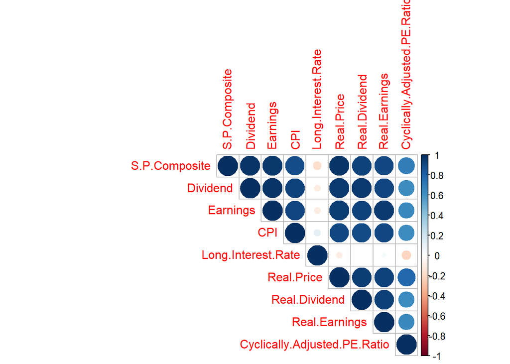

```r
SPCompositeCorrelation <- cor(SPComposite %>% select(-Year))
corrplot(SPCompositeCorrelation, type = "upper")
```

```r
SPComposite <- SPComposite %>%
  rename(SPComposite = S.P.Composite, LongInterestRate = Long.Interest.Rate) %>%
  select(Year, SPComposite, LongInterestRate)
```

# Podstawowe statystyki zbiorów

## World Development Indicators

Ilość obserwacji: 5253  
Ilość atrybutów: 18

```r
WorldDevelopmentIndicatorsAttributesCount <-
  ncol(WorldDevelopmentIndicators)
for (i in seq(1, WorldDevelopmentIndicatorsAttributesCount, by = 10)) {
  if (i != WorldDevelopmentIndicatorsAttributesCount) {
    if (i < WorldDevelopmentIndicatorsAttributesCount - 9) {
      WorldDevelopmentIndicatorsPart <-
        WorldDevelopmentIndicators[, i:(i + 9)]
    } else {
      WorldDevelopmentIndicatorsPart <-
        WorldDevelopmentIndicators[, i:WorldDevelopmentIndicatorsAttributesCount]
    }
    print(knitr::kable(summary(WorldDevelopmentIndicatorsPart)))
    cat("\n")
  }
}
```

|  | CountryName | Year | Birth rate, crude (per 1,000 people) | CO2 emissions (metric tons per capita) | Exports of goods and services (current US Dollar per capita) | GDP per capita (current US Dollar) | Imports of goods and services (current US Dollar per capita) | Land area (sq. km) | Life expectancy at birth, total (years) | Merchandise exports to high-income economies (% of total merchandise exports) |
| --- | --- | --- | --- | --- | --- | --- | --- | --- | --- | --- |
|  | Length:5253 | Min. :1970 | Min. : 5.90 | Min. : 0.0043 | Min. : 0.03 | Min. : 22.8 | Min. : 0.09 | Min. : 320 | Min. :18.91 | Min. : 0.2453 |
|  | Class :character | 1st Qu.:1982 | 1st Qu.:13.10 | 1st Qu.: 0.8277 | 1st Qu.: 224.72 | 1st Qu.: 925.6 | 1st Qu.: 288.66 | 1st Qu.: 68890 | 1st Qu.:62.90 | 1st Qu.:57.0681 |
|  | Mode :character | Median :1995 | Median :20.79 | Median : 2.8486 | Median : 922.96 | Median : 2812.3 | Median : 1087.26 | Median : 230080 | Median :70.21 | Median :72.5705 |
|  | NA | Mean :1995 | Mean :23.66 | Mean : 4.3377 | Mean : 4275.40 | Mean : 8739.6 | Mean : 4067.91 | Mean : 966368 | Mean :67.97 | Mean :68.1650 |
|  | NA | 3rd Qu.:2008 | 3rd Qu.:33.39 | 3rd Qu.: 6.8852 | 3rd Qu.: 3572.67 | 3rd Qu.: 9785.9 | 3rd Qu.: 3718.13 | 3rd Qu.: 769630 | 3rd Qu.:74.56 | 3rd Qu.:83.0205 |
|  | NA | Max. :2020 | Max. :51.09 | Max. :26.8993 | Max. :118062.82 | Max. :102913.4 | Max. :98872.32 | Max. :16389950 | Max. :83.75 | Max. :99.8726 |
|  | NA | NA | NA’s :127 | NA’s :647 | NA’s :821 | NA’s :737 | NA’s :821 | NA | NA’s :131 | NA’s :755 |

|  | Methane emissions (kt of CO2 equivalent per capita) | Nitrous oxide emissions (thousand metric tons of CO2 equivalent per capita) | Number of under-five deaths (per capita) | Population density (people per sq. km of land area) | Population growth (annual %) | Primary school starting age (years) | Total greenhouse gas emissions (kt of CO2 equivalent per capita) | Total natural resources rents (% of GDP) |
| --- | --- | --- | --- | --- | --- | --- | --- | --- |
|  | Min. :0.00018 | Min. :0.00007 | Min. :0.0000 | Min. : 0.823 | Min. :-3.8477 | Min. :4.000 | Min. :0.00081 | Min. : 0.0000 |
|  | 1st Qu.:0.00078 | 1st Qu.:0.00031 | 1st Qu.:0.0001 | 1st Qu.: 26.061 | 1st Qu.: 0.4619 | 1st Qu.:6.000 | 1st Qu.:0.00283 | 1st Qu.: 0.3985 |
|  | Median :0.00113 | Median :0.00049 | Median :0.0006 | Median : 69.564 | Median : 1.2877 | Median :6.000 | Median :0.00581 | Median : 1.6641 |
|  | Mean :0.00150 | Mean :0.00075 | Mean :0.0017 | Mean : 163.321 | Mean : 1.3640 | Mean :6.306 | Mean :0.00779 | Mean : 5.1965 |
|  | 3rd Qu.:0.00165 | 3rd Qu.:0.00094 | 3rd Qu.:0.0024 | 3rd Qu.: 114.891 | 3rd Qu.: 2.3410 | 3rd Qu.:7.000 | 3rd Qu.:0.01050 | 3rd Qu.: 5.6679 |
|  | Max. :0.00986 | Max. :0.01001 | Max. :0.0135 | Max. :8044.526 | Max. : 6.5591 | Max. :8.000 | Max. :0.05603 | Max. :87.5074 |
|  | NA’s :226 | NA’s :226 | NA’s :458 | NA | NA’s :1 | NA’s :37 | NA’s :262 | NA’s :802 |

## Bitcoin Prices

Ilość obserwacji: 13  
Ilość atrybutów: 2

```r
knitr::kable(summary(BitcoinPrices))
```

|  | Year | BitcoinPrice |
| --- | --- | --- |
|  | Min. :2009 | Min. : 0.00 |
|  | 1st Qu.:2012 | 1st Qu.: 8.47 |
|  | Median :2015 | Median : 525.60 |
|  | Mean :2015 | Mean : 5855.95 |
|  | 3rd Qu.:2018 | 3rd Qu.: 7362.71 |
|  | Max. :2021 | Max. :44591.33 |

## Gold Prices

Ilość obserwacji: 53  
Ilość atrybutów: 2

```r
knitr::kable(summary(GoldPrices))
```

|  | Year | GoldPrice |
| --- | --- | --- |
|  | Min. :1969 | Min. : 35.96 |
|  | 1st Qu.:1982 | 1st Qu.: 294.08 |
|  | Median :1995 | Median : 383.66 |
|  | Mean :1995 | Mean : 591.09 |
|  | 3rd Qu.:2008 | 3rd Qu.: 872.15 |
|  | Max. :2021 | Max. :1800.51 |

## S&P Composite

Ilość obserwacji: 141  
Ilość atrybutów: 3

```r
knitr::kable(summary(SPComposite))
```

|  | Year | SPComposite | LongInterestRate |
| --- | --- | --- | --- |
|  | Min. :1881 | Min. : 4.233 | Min. : 0.8942 |
|  | 1st Qu.:1916 | 1st Qu.: 8.573 | 1st Qu.: 3.1367 |
|  | Median :1951 | Median : 24.497 | Median : 3.6667 |
|  | Mean :1951 | Mean : 355.396 | Mean : 4.4816 |
|  | 3rd Qu.:1986 | 3rd Qu.: 236.358 | 3rd Qu.: 5.0175 |
|  | Max. :2021 | Max. :4114.705 | Max. :13.9108 |

# Ocena wartości atrybutów

## World Development Indicators

Analiza atrybutów na przestrzeni lat: porównianie dla pięciu krajów o różnej zamożności.

```r
GdpStats <- WorldDevelopmentIndicators %>%
  group_by(CountryName) %>%
  summarize(GdpMean = mean(`GDP per capita (current US Dollar)`, na.rm = TRUE))
SelectedCountries <- c()
for (i in seq(0, 1, 0.25)) {
  CountryToAdd <- GdpStats %>%
    filter(abs(GdpMean - quantile(GdpMean, i)) == min(abs(GdpMean - quantile(GdpMean, i))))
  SelectedCountries <-
    c(SelectedCountries, CountryToAdd$CountryName[1])
}
PlotData <- WorldDevelopmentIndicatorsNotSpread %>%
  filter(CountryName %in% SelectedCountries)
for (item in unique(WorldDevelopmentIndicatorsNotSpread$SeriesName)) {
  PlotDataForSeries <- PlotData %>%
    filter(SeriesName == item)
  cat("\n")
  cat("### ", item)
  cat("\n")
  print(ggplot(PlotDataForSeries, aes(Year, Value, color = CountryName)) + geom_line() + geom_point())
  cat("\n")
}
```

### Birth rate, crude (per 1,000 people)

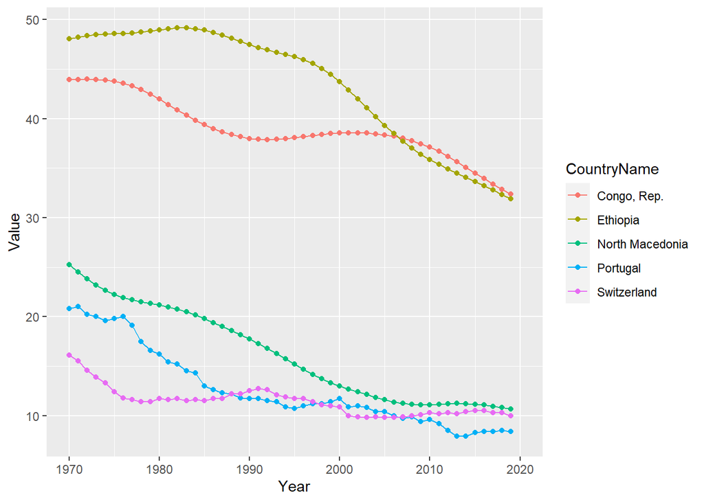

### CO2 emissions (metric tons per capita)

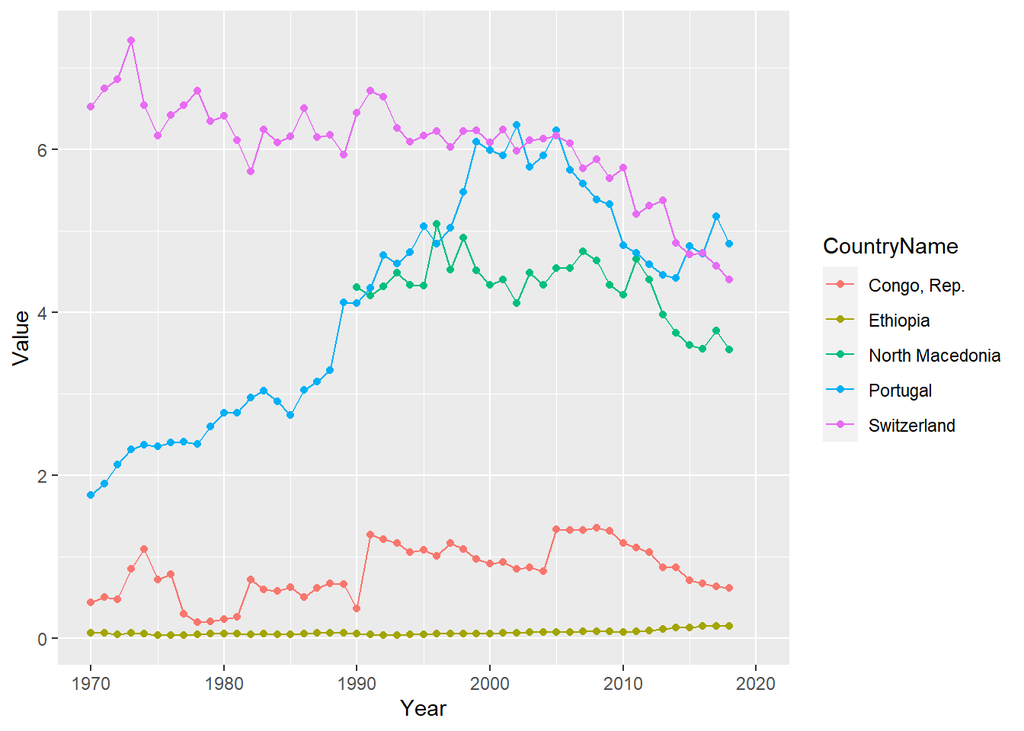

### Exports of goods and services (current US Dollar per capita)

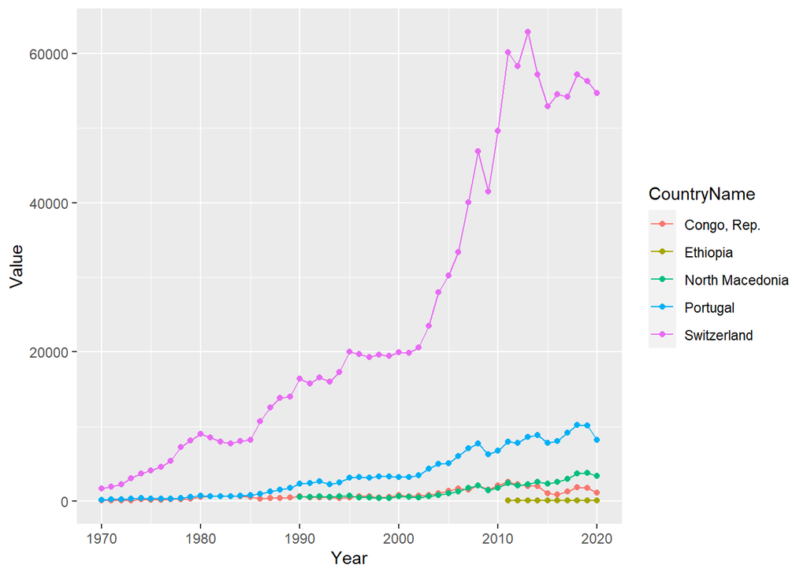

### GDP per capita (current US Dollar)

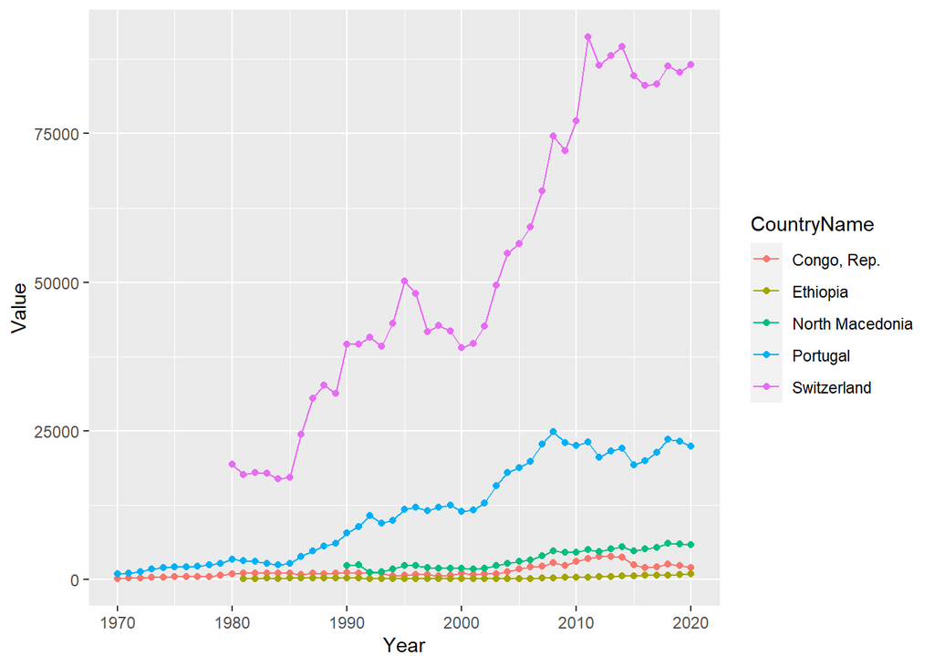

### Imports of goods and services (current US Dollar per capita)

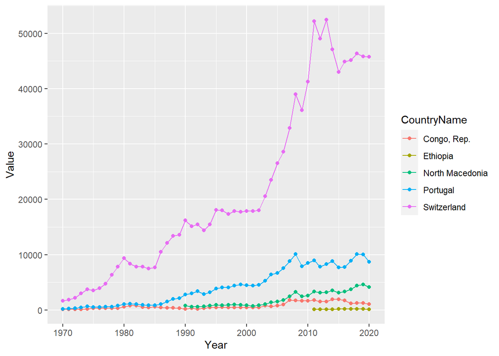

### Land area (sq. km)

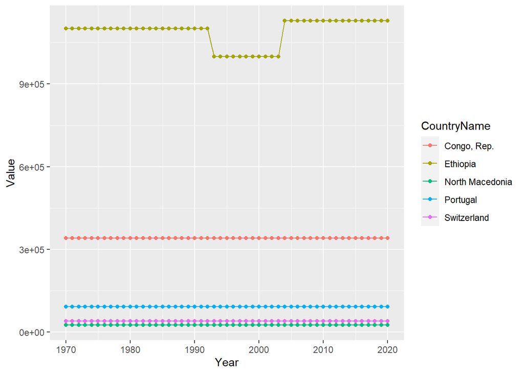

### Life expectancy at birth, total (years)

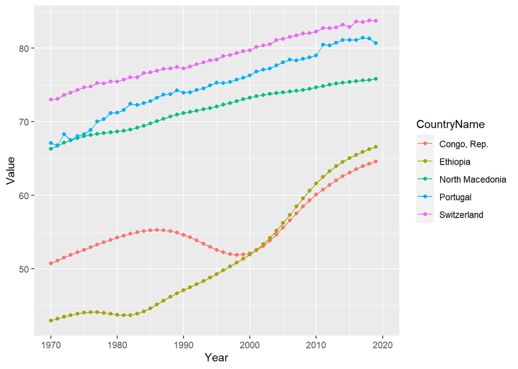

### Merchandise exports to high-income economies (% of total merchandise exports)

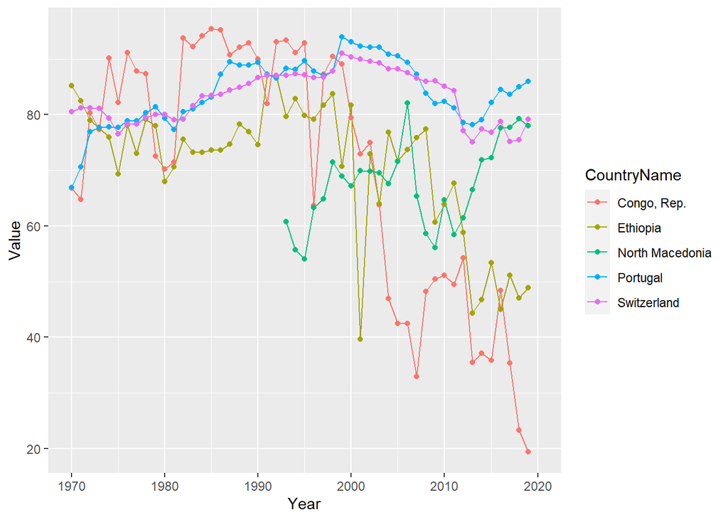

### Methane emissions (kt of CO2 equivalent per capita)

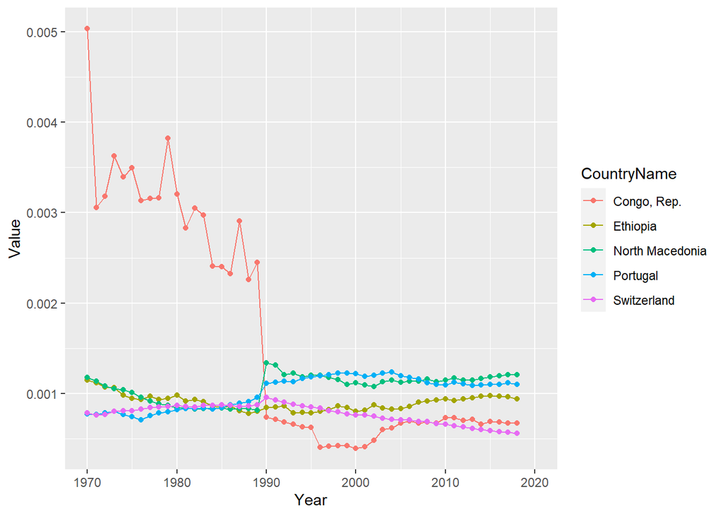

### Nitrous oxide emissions (thousand metric tons of CO2 equivalent per capita)

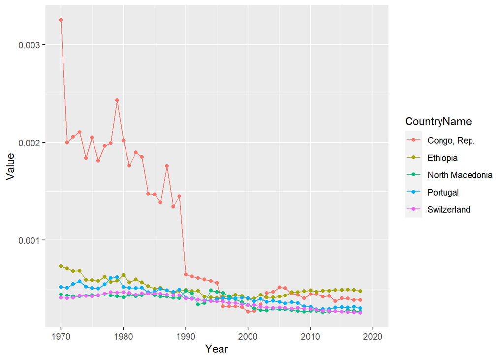

### Number of under-five deaths (per capita)

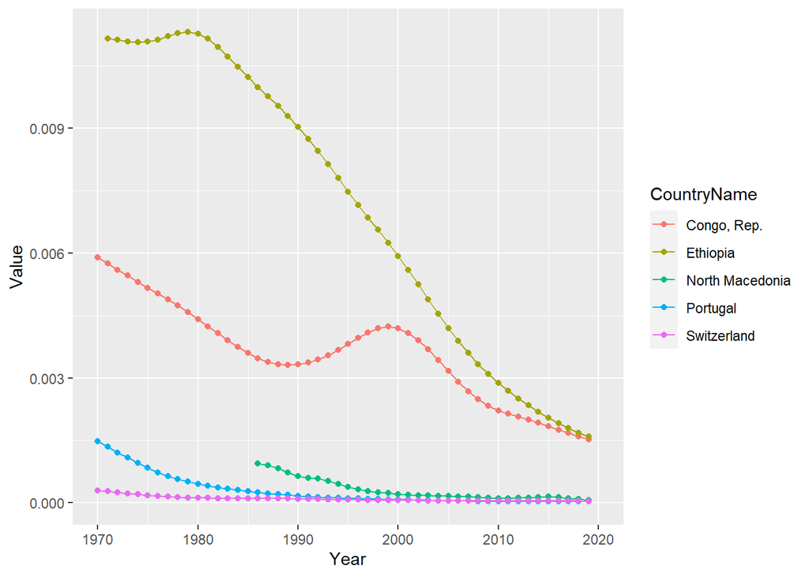

### Population density (people per sq. km of land area)

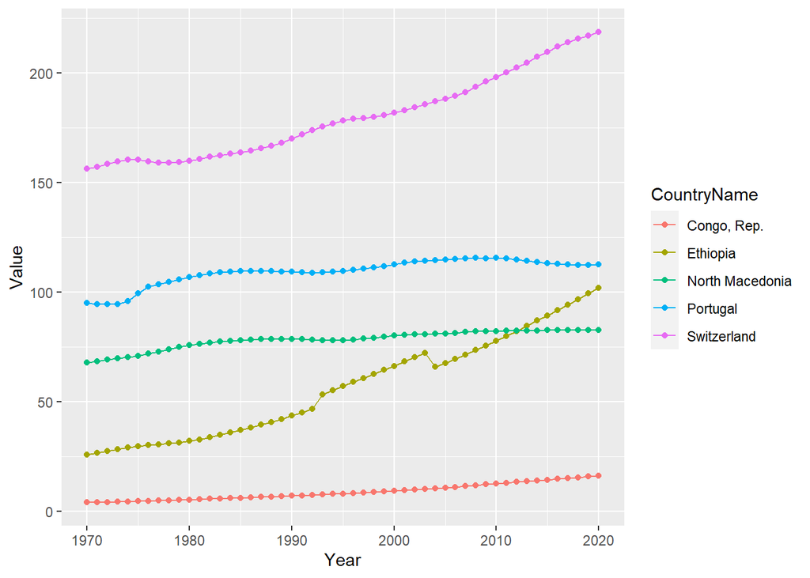

### Population growth (annual %)

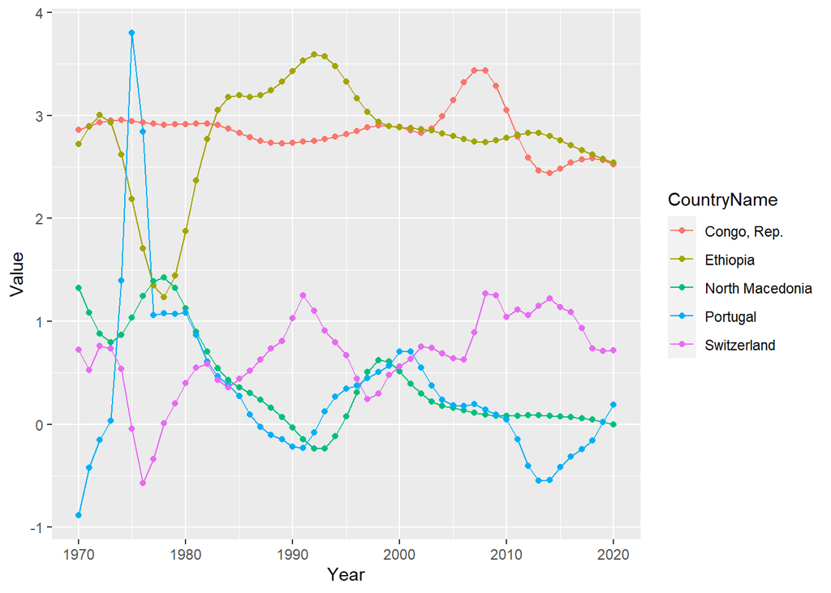

### Primary school starting age (years)

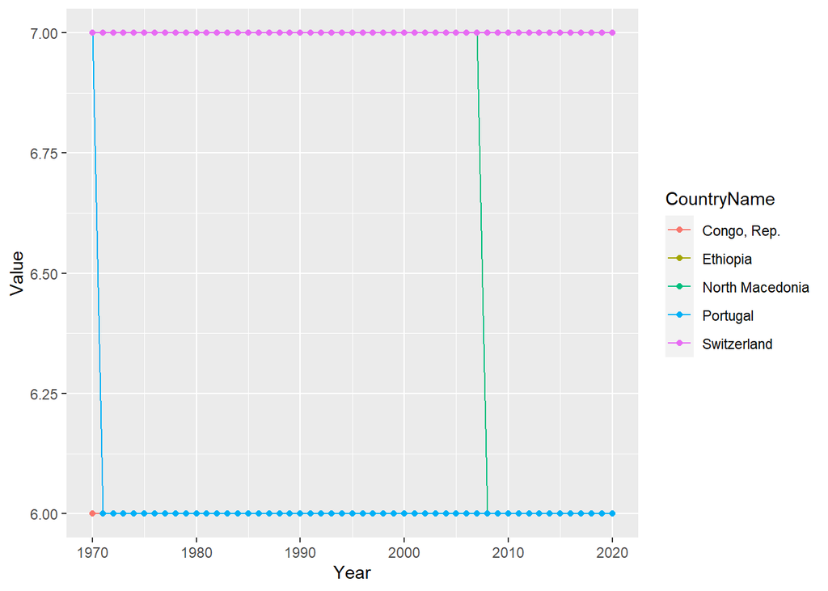

### Total greenhouse gas emissions (kt of CO2 equivalent per capita)

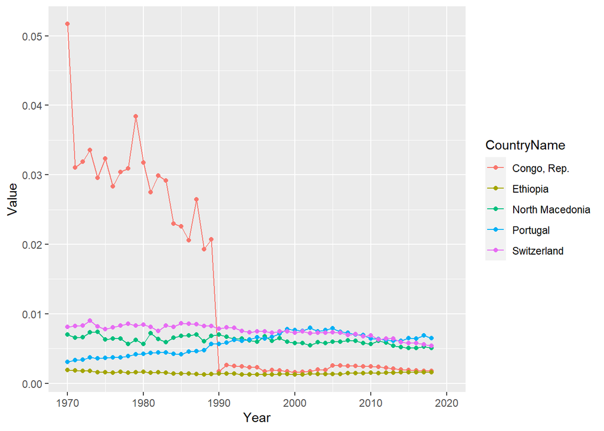

### Total natural resources rents (% of GDP)

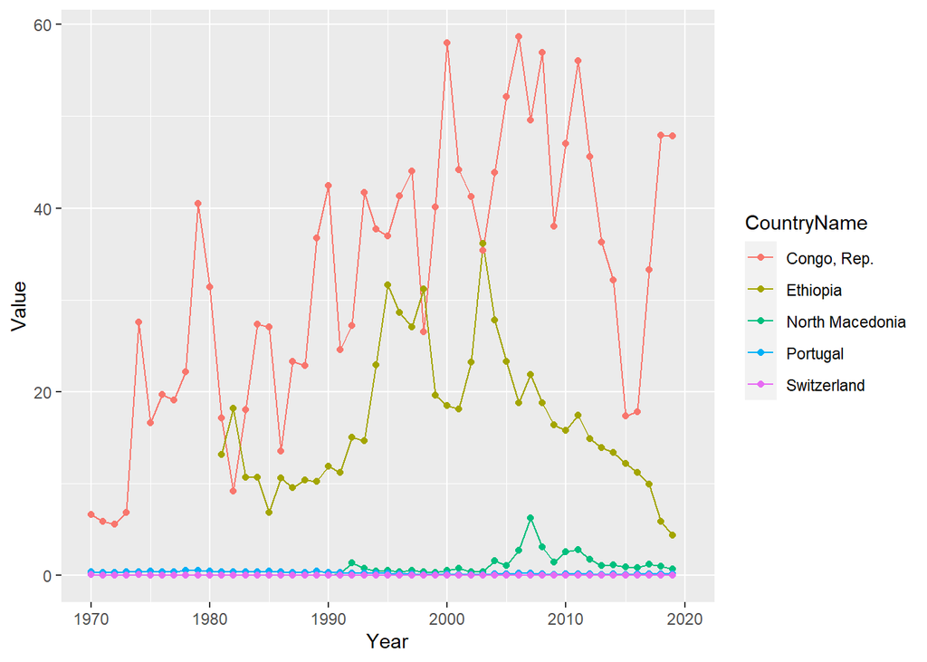

## Bitcoin Prices

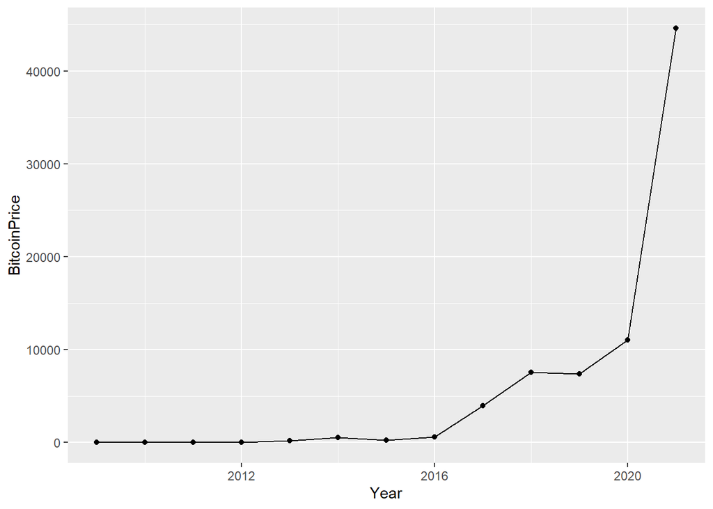

```r
ggplot(BitcoinPrices, aes(Year, BitcoinPrice)) + geom_line() + geom_point()
```

## Gold Prices

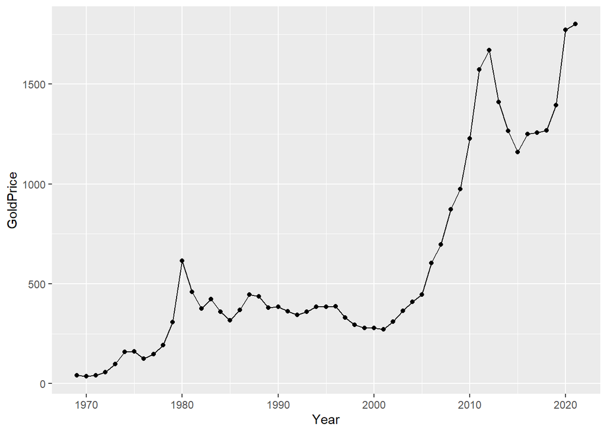

```r
ggplot(GoldPrices, aes(Year, GoldPrice)) + geom_line() + geom_point()
```

## S&P Composite

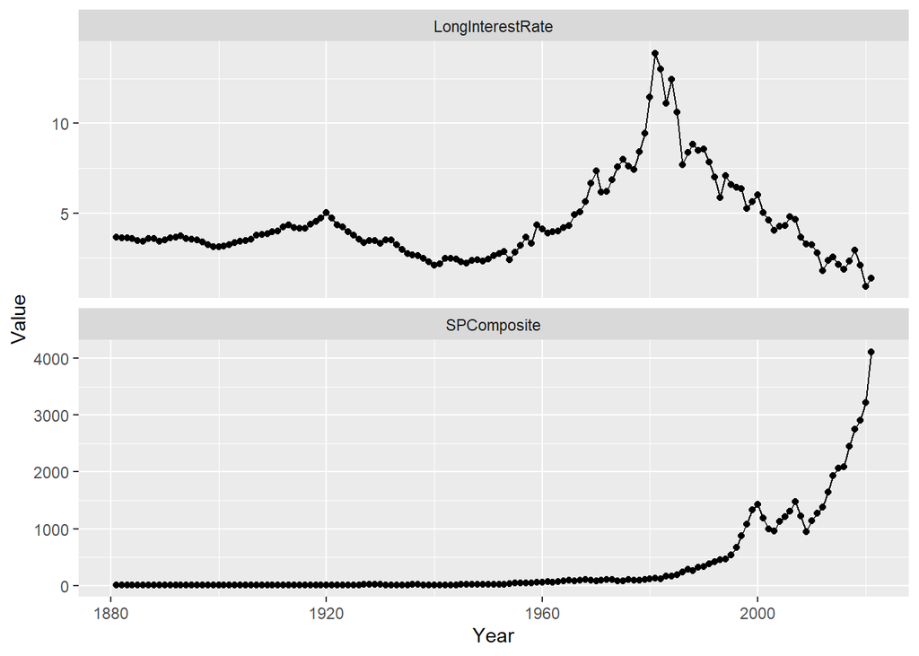

```r
SPCompositeGathered <-
  SPComposite %>% gather("Attribute", "Value", SPComposite:LongInterestRate)
ggplot(SPCompositeGathered, aes(Year, Value)) + geom_line() + geom_point() + facet_wrap( ~
                                                                                           Attribute, scales = "free_y", ncol = 1)
```

# Korelacje między zmiennymi

## Korelacja z ceną złota i bitcoina

Biorąc pod uwagę wartości atrybutów ze wszystkich krajów, zauważono bardzo małą korelację, największą korelację,zarówno z ceną złota, jak i z ceną bitcoina wykazują parametry Year, SPComposite oraz LongInterestRate (korelację odwrotną), czyli parametry nie mające podziału na kraje. Jest to spodziewany wynik, ponieważ dla każdego kraju ceny złota i bitcoina odpowiadają różnym wartościom poszczególnych atrybutów dla różnych krajów, co nie sprzyja wysokiej korelacji.

```r
MainTable <-
  WorldDevelopmentIndicators %>% left_join(BitcoinPrices, by = "Year")
MainTable <- MainTable %>% left_join(GoldPrices, by = "Year")
MainTable <- MainTable %>% left_join(SPComposite, by = "Year")
MainTableX <-
  MainTable %>% select(-CountryName,-BitcoinPrice,-GoldPrice)
MainTableY <- MainTable %>% select(BitcoinPrice, GoldPrice)
GoldAndBitcoinCorr <-
  cor(MainTableX, MainTableY, use = "pairwise.complete.obs")
knitr::kable(GoldAndBitcoinCorr)
```

|  | BitcoinPrice | GoldPrice |
| --- | --- | --- |
| Year | 0.8451796 | 0.8260518 |
| Birth rate, crude (per 1,000 people) | -0.0708717 | -0.2736911 |
| CO2 emissions (metric tons per capita) | -0.0144585 | 0.0214218 |
| Exports of goods and services (current US Dollar per capita) | 0.0342048 | 0.2753072 |
| GDP per capita (current US Dollar) | 0.0229491 | 0.3243418 |
| Imports of goods and services (current US Dollar per capita) | 0.0331398 | 0.2919800 |
| Land area (sq. km) | -0.0001729 | -0.0008086 |
| Life expectancy at birth, total (years) | 0.0951495 | 0.3542683 |
| Merchandise exports to high-income economies (% of total merchandise exports) | -0.0156605 | -0.2291750 |
| Methane emissions (kt of CO2 equivalent per capita) | -0.0137187 | -0.0644905 |
| Nitrous oxide emissions (thousand metric tons of CO2 equivalent per capita) | -0.0097028 | -0.1196450 |
| Number of under-five deaths (per capita) | -0.0790781 | -0.3077304 |
| Population density (people per sq. km of land area) | 0.0084970 | 0.0503981 |
| Population growth (annual %) | -0.0454153 | -0.1587009 |
| Primary school starting age (years) | -0.0161784 | -0.1206927 |
| Total greenhouse gas emissions (kt of CO2 equivalent per capita) | -0.0140730 | -0.1062787 |
| Total natural resources rents (% of GDP) | -0.0601282 | 0.0203403 |
| SPComposite | 0.8888081 | 0.7996193 |
| LongInterestRate | -0.4854847 | -0.6664436 |

## Korelacja parametrów z ceną złota dla poszczególnych krajów

Poprzez wyznaczenie sum wartości bezwzględnych współczynników korelacji dla każdego kraju, wyznaczono kraj, którego wskaźniki rozwoju są najbardziej skorelowane z ceną złota. Wybrano cenę złota, ponieważ ta zmienna zawiera więcej obserwacji niż cena Bitcoina.

```r
WorldDevelopmentIndicatorsWithGoldPrice <-
  WorldDevelopmentIndicators %>% left_join(GoldPrices, by = "Year")
Countries <-
  unique(WorldDevelopmentIndicatorsWithGoldPrice$CountryName)
CorrelationSumVector <- c()
MaxCorSum <- 0
for (country in Countries) {
  FilteredByCountry <-
    WorldDevelopmentIndicatorsWithGoldPrice %>% filter(CountryName == country)
  CorRes <-
    cor(
      FilteredByCountry %>% select(-GoldPrice,-CountryName,-Year),
      FilteredByCountry %>% select(GoldPrice),
      use = "pairwise.complete.obs"
    )
  CorSum <- sum(abs(CorRes), na.rm = TRUE)
  CorrelationSumVector <- c(CorrelationSumVector, CorSum)
  if (CorSum > MaxCorSum) {
    MaxCorSum <- CorSum
    MaxCorRes <- CorRes
  }
}
CorSums <- data.frame(Countries, CorrelationSumVector)
knitr::kable(CorSums %>% arrange(-CorrelationSumVector))
```

| Countries | CorrelationSumVector |
| --- | --- |
| United States | 11.752297 |
| Belgium | 11.546577 |
| Denmark | 11.282170 |
| China | 11.262512 |
| Switzerland | 11.220028 |
| Nepal | 11.181921 |
| India | 10.825624 |
| Netherlands | 10.783719 |
| Philippines | 10.738375 |
| Thailand | 10.727484 |
| Panama | 10.717949 |
| Korea, Rep. | 10.693141 |
| Paraguay | 10.532498 |
| Brazil | 10.507950 |
| North Macedonia | 10.506908 |
| Honduras | 10.450572 |
| Norway | 10.435025 |
| Guatemala | 10.385797 |
| Myanmar | 10.367406 |
| Singapore | 10.355215 |
| Romania | 10.321548 |
| France | 10.251924 |
| Bolivia | 10.196410 |
| Mauritius | 10.152928 |
| Colombia | 10.116100 |
| Azerbaijan | 10.113170 |
| Hungary | 10.042101 |
| Ghana | 10.014710 |
| Mongolia | 9.948533 |
| Turkey | 9.942970 |

[output cut: 73 more lines]

Podsumowując, cena złota najbardziej zależy od rozwoju Stanów Zjednoczonych.

# Przedstawienie wybranych atrybutów w czasie

Przedstawienie wskaźników rozwoju dla Stanów Zjednoczonych najbardziej skorelowaneych z ceną złota i ich zmienności względem zmienności ceny złota.

[figure not shown]

```r
USMainTable <- MainTable %>% filter(CountryName == "United States")
MaxCorResDf <- data.frame(MaxCorRes)
MaxCorResDf <-
  MaxCorResDf[order(abs(MaxCorResDf$GoldPrice), decreasing = TRUE), , drop =
                FALSE]
MostCorrelatedAttributes <- rownames(MaxCorResDf[1:3, , drop = FALSE])
USMainTableGathered <- USMainTable %>%
  gather("Attribute",
         "Value",
         `Birth rate, crude (per 1,000 people)`:LongInterestRate) %>%
  filter(Attribute %in% MostCorrelatedAttributes |
           Attribute == "GoldPrice")
plot <-
  ggplot(USMainTableGathered, aes(Year, Value)) + geom_point() + facet_wrap( ~
                                                                               Attribute,
                                                                             scales = "free_y",
                                                                             labeller = label_wrap_gen(width = 50, multi_line = TRUE)) + transition_time(Year) + shadow_mark()
animate(plot)
```

# Stworzenie regresora przewidującego cenę złota.

## Ograniczenie ilości atrybutów

- Usunięcie atrybutów o małej zmienności.
- Ograniczenie atrybutów skorelowanych ze sobą.
- Wypełnienie wartości pustych poprzednimi lub następnymi wartościami.

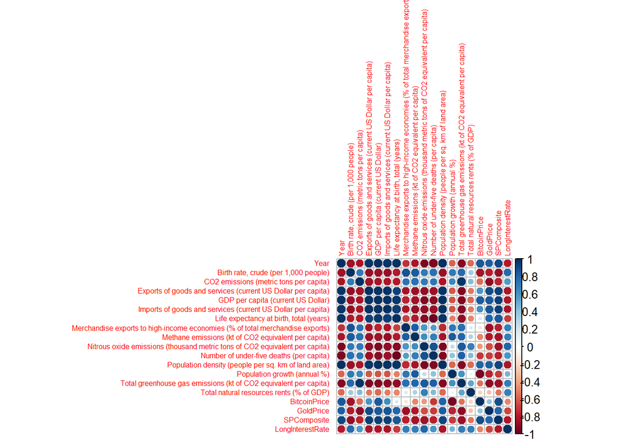

```r
USMainTableML <-
  USMainTable %>% select(-`Primary school starting age (years)`,
                         -`Land area (sq. km)`,
                         -CountryName)
CorResUS <- cor(USMainTableML, use = "pairwise.complete.obs")
corrplot(CorResUS, tl.cex = 0.5)
```

Zauważono grupę sześciu atrybutów silnie skorelowanych ze sobą: Year, Imports of goods and services (current US Dollar per capita), GDP per capita (current US Dollar), Life expectancy at birth, total (years), Population density (people per sq. km of land area), Exports of goods and services (current US Dollar per capita). Postanowiono wybrać jeden z nich oraz dodatkowo kolumnę Year, ponieważ jest ona identyfikatorem.

```r
USMainTableML <-
  USMainTableML %>% select(
    -`Imports of goods and services (current US Dollar per capita)`,
    -`GDP per capita (current US Dollar)`,
    -`Life expectancy at birth, total (years)`,
    -`Population density (people per sq. km of land area)`
  )
USMainTableML <- na.locf(USMainTableML, na.rm = FALSE)
USMainTableML <- na.locf(USMainTableML, na.rm = FALSE, fromLast = TRUE)
```

## Stworzenie danych treningowych i testowych

```r
inTraining <-
  createDataPartition(y = USMainTableML$GoldPrice,
                      p = .75,
                      list = FALSE)
training <- USMainTableML[inTraining, ]
testing  <- USMainTableML[-inTraining, ]
```

## Schemat uczenia

```r
ctrl <- trainControl(method = "repeatedcv",
                     number = 2,
                     repeats = 5)
```

## Uczenie

Jako miarę oceny wybrano miarę R squared, ponieważ jest to miara względna, przez co łatwiejsza do interpretacji dla odbiorcy.

```r
tunegrid <- expand.grid(mtry = 1:10)
BestModel <- NA
maxRsquared <- 0
for (i in seq(1, 100)) {
  model <- train(
    GoldPrice ~ .,
    data = training,
    method = "rf",
    trControl = ctrl,
    tuneGrid = tunegrid,
    metric = "Rsquared",
    ntree = i
  )
  iterationMaxRsquared <-
    model$results[which.max(model$results[, "Rsquared"]), ]$Rsquared
  if (maxRsquared < iterationMaxRsquared) {
    maxRsquared <- iterationMaxRsquared
    BestModel <- model
  }
}
print(BestModel)
```

Random Forest

39 samples 14 predictors

No pre-processing Resampling: Cross-Validated (2 fold, repeated 5 times) Summary of sample sizes: 20, 19, 19, 20, 19, 20, … Resampling results across tuning parameters:

mtry RMSE Rsquared MAE  
1 167.6896 0.9457429 124.2826 2 156.9579 0.9571996 111.8293 3 152.8043 0.9602681 108.6085 4 158.8890 0.9553215 112.4928 5 156.2602 0.9568854 111.0097 6 156.4621 0.9593594 108.9915 7 159.0617 0.9562618 112.6921 8 154.8656 0.9567877 111.0560 9 158.8239 0.9561217 112.9913 10 156.5723 0.9555242 111.7673

Rsquared was used to select the optimal model using the largest value. The final value used for the model was mtry = 3.

```r
print(BestModel$finalModel)
```

Call: randomForest(x = x, y = y, ntree = ..1, mtry = min(param$mtry, ncol(x))) Type of random forest: regression Number of trees: 82 No. of variables tried at each split: 3

```
      Mean of squared residuals: 12871.9
                % Var explained: 94.64
```

## Testowanie

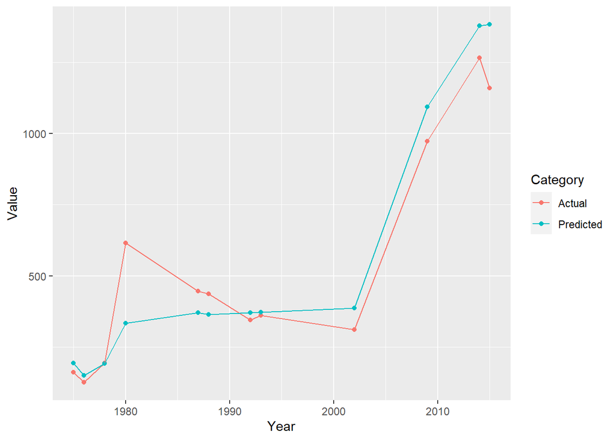

```r
predictions <- predict(BestModel, newdata = testing)
testingRsquared <- cor(testing$GoldPrice, predictions) ^ 2
resultsDf <-
  data.frame(
    Year = testing$Year,
    Actual = testing$GoldPrice,
    Predicted = predictions
  )
resultsDf <-
  resultsDf %>% gather("Category", "Value", Actual:Predicted)
ggplot(resultsDf, aes(Year, Value, color = Category)) + geom_point() + geom_line()
```

R squared dla modelu: 0.9602681, R squared dla predykcji: 0.937398.

# Ocena ważności atrybutów

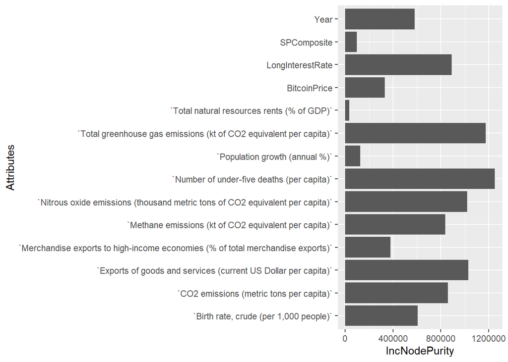

```r
variablesImportance <- importance(BestModel$finalModel)
variablesImportanceDf <-
  data.frame(rownames(variablesImportance), variablesImportance) %>% rename(Attributes = rownames.variablesImportance.)
ggplot(variablesImportanceDf, aes(Attributes, IncNodePurity)) + geom_bar(stat =
                                                                           "identity") + coord_flip()
```

Obok atrybutów mówiących o rozwoju kraju o dość wysokiej ważności, której można było się spodziewać, np. emisja gazów cieplarnianych lub eksport dóbr i usług, najwyższą ważność osiągnął atrybut opisujący liczbę śmierci przed piątym rokiem życia. Może to być spowodowane tym, że ta statystyka jest powiązana często ze stanem służby zdrowia, ale też z ogólną zamożnością obywateli, ponieważ w USA na przestrzeni lat większa część opieki zdrowotnej nie była finansowana przez rząd. Najniższą ważność uzyskał czynsz za zasoby naturalne, współczynnik S&P Composite oraz wzrost populacji.